# Homework 7

INFO 5871-001

Fall 2019

*Keke Wu*

```python
import numpy as np
import scipy.stats as st
import pandas as pd
import matplotlib.pyplot as plt
import seaborn as sns
from statsmodels.stats.power import TTestIndPower
from statsmodels.stats.multicomp import MultiComparison
from scipy import stats
%matplotlib inline
```

## Home values

This is the familiar Ames home sales data set. We are going to treat home sales as a sample of home values. There are some problems with this assumption. There may be many non-random effects causing people to sell.

```python
columns = ['Neighborhood', 'Bldg.Type', 'House.Style', 'Gr.Liv.Area', 'SalePrice']

ames_original = pd.read_csv('ames.csv', usecols=columns)
```

```python
drop_anomaly = ames_original['Gr.Liv.Area'] <= 4000
# We use copy here because we will be modifying the data frame later
ames = ames_original[drop_anomaly].copy()
print (ames.shape)
ames.head()
```

```
(2925, 5)
```

|  | Neighborhood | Bldg.Type | House.Style | Gr.Liv.Area | SalePrice |
| --- | --- | --- | --- | --- | --- |
| 0 | NAmes | 1Fam | 1Story | 1656 | 215000 |
| 1 | NAmes | 1Fam | 1Story | 896 | 105000 |
| 2 | NAmes | 1Fam | 1Story | 1329 | 172000 |
| 3 | NAmes | 1Fam | 1Story | 2110 | 244000 |
| 4 | Gilbert | 1Fam | 2Story | 1629 | 189900 |

## Question 1: What is the mean and 95% confidence interval for sale price?

You will have to use the `t` distribution and use the formula below. Remember that we use `ppf` to point at which the area under the distribution curve reaches a particular value.

$\bar{x} \pm t^* * \frac{s}{\sqrt{n}}$

where $s$ is the standard deviation of $x$.

Hint: The upper limit of the confidence interval should be around \$183,250.

```python
mn = ames.SalePrice.mean()
mn
```

```
180411.5747008547
```

```python
cnt = ames.shape[0]
cnt
```

```
2925
```

```python
se = ames.SalePrice.std() / np.sqrt(cnt)
se
```

```
1452.4798250303313
```

```python
tstar = st.t.ppf(0.025, cnt-1)
tstar
```

```
-1.960775625038038
```

```python
interval = (mn + (tstar * se), mn-(tstar * se))
interval
```

```
(177563.5876640757, 183259.5617376337)
```

## Question 2: Compare normalized prices for 1 story and 2 story houses

### Aggregate over house types

As in Homework 4, separate the Single Family houses and create an `NStyle` column that combines different types of split, 1 story and 2 story houses.

```python
single_family = ames[ames['Bldg.Type'] == '1Fam'].copy()
single_family.head()
```

|  | Neighborhood | Bldg.Type | House.Style | Gr.Liv.Area | SalePrice |
| --- | --- | --- | --- | --- | --- |
| 0 | NAmes | 1Fam | 1Story | 1656 | 215000 |
| 1 | NAmes | 1Fam | 1Story | 896 | 105000 |
| 2 | NAmes | 1Fam | 1Story | 1329 | 172000 |
| 3 | NAmes | 1Fam | 1Story | 2110 | 244000 |
| 4 | Gilbert | 1Fam | 2Story | 1629 | 189900 |

```python
single_family['NStyle'] = 'Split Level'
split_filter = (single_family['House.Style'] == 'SFoyer') | (single_family['House.Style'] == 'SLvl')
single_family.loc[split_filter, 'NStyle'] = 'Split Level'
one_story_filter = ((single_family['House.Style'] == '1.5Fin') | (single_family['House.Style'] == '1Story'))
single_family.loc[one_story_filter, 'NStyle'] = '1 Story'
two_story_filter = (single_family['House.Style'] == '2.5Unf') | (single_family['House.Style'] == '2.5Fin') | (single_family['House.Style'] == '2Story')
single_family.loc[two_story_filter, 'NStyle'] = '2 Story'
single_family.head()
```

|  | Neighborhood | Bldg.Type | House.Style | Gr.Liv.Area | SalePrice | NStyle |
| --- | --- | --- | --- | --- | --- | --- |
| 0 | NAmes | 1Fam | 1Story | 1656 | 215000 | 1 Story |
| 1 | NAmes | 1Fam | 1Story | 896 | 105000 | 1 Story |
| 2 | NAmes | 1Fam | 1Story | 1329 | 172000 | 1 Story |
| 3 | NAmes | 1Fam | 1Story | 2110 | 244000 | 1 Story |
| 4 | Gilbert | 1Fam | 2Story | 1629 | 189900 | 2 Story |

### Create a price per square foot column

```python
single_family['PriceSqFt'] = single_family['SalePrice'] / single_family['Gr.Liv.Area']
single_family.head()
```

|  | Neighborhood | Bldg.Type | House.Style | Gr.Liv.Area | SalePrice | NStyle | PriceSqFt |
| --- | --- | --- | --- | --- | --- | --- | --- |
| 0 | NAmes | 1Fam | 1Story | 1656 | 215000 | 1 Story | 129.830918 |
| 1 | NAmes | 1Fam | 1Story | 896 | 105000 | 1 Story | 117.187500 |
| 2 | NAmes | 1Fam | 1Story | 1329 | 172000 | 1 Story | 129.420617 |
| 3 | NAmes | 1Fam | 1Story | 2110 | 244000 | 1 Story | 115.639810 |
| 4 | Gilbert | 1Fam | 2Story | 1629 | 189900 | 2 Story | 116.574586 |

### Calculate mean price per sqft for each `NStyle` type

Use `groupby` and `agg`.

```python
price_nstyle_gr = single_family.groupby('NStyle')
mean = price_nstyle_gr.agg('mean')['PriceSqFt']
print(mean)
```

```
NStyle
1 Story        125.356612
2 Story        113.402847
Split Level    129.402510
Name: PriceSqFt, dtype: float64
```

### Is the difference between the mean PPSqFt for 1Story and 2Story significant?

Use `ttest_ind`, $\alpha=0.05$ (the default).

```python
groups = price_nstyle_gr['PriceSqFt'].apply(list)
groups
```

```
NStyle
1 Story        [129.83091787439614, 117.1875, 129.42061700526...
2 Story        [116.57458563535911, 121.88279301745636, 104.7...
Split Level    [144.92753623188406, 134.27947598253274, 125.8...
Name: PriceSqFt, dtype: object
```

```python
stds = price_nstyle_gr.agg('std')['PriceSqFt']
stds
```

```
NStyle
1 Story        33.299048
2 Story        22.944254
Split Level    24.808773
Name: PriceSqFt, dtype: float64
```

```python
st.ttest_ind(groups["1 Story"], groups["2 Story"])
```

```
Ttest_indResult(statistic=8.7173653807693, pvalue=5.449853802628117e-18)
```

*The p value is less than 0.05, so we reject the null hypothesis, and conclude that there is a significant difference between the mean PPSqFt for 1 Story and 2 Story houses.*

### Are the conditions met?

- We are assuming that people's individual choice to sell their house is a random act.
- Is number of observations in each group > 30? Check with `value_counts` or with `.size()` on the grouped data.
- Are there *particularly* extreme outliers? Use `distplot` and `probplot` to examine the distributions.

```python
szs = price_nstyle_gr.size()
szs
```

```
NStyle
1 Story        1510
2 Story         724
Split Level     186
dtype: int64
```

```python
se = np.sqrt((np.square(stds) / szs).sum())
se
```

```
2.184136945127827
```

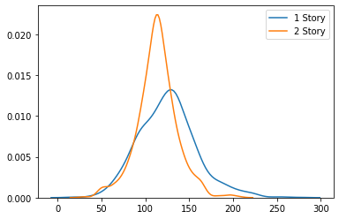

```python
sns.distplot(groups['1 Story'], hist=False, label='1 Story');
sns.distplot(groups['2 Story'], hist=False, label='2 Story');
```

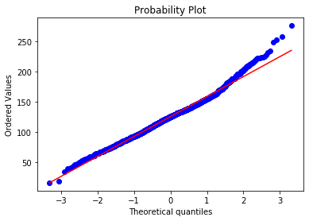

```python
ax = st.probplot(groups['1 Story'], dist="norm", plot=plt);
```

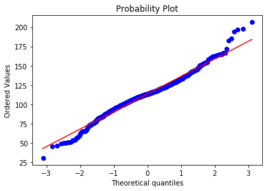

```python
ax = st.probplot(groups['2 Story'], dist="norm", plot=plt);
```

### Conclusion

*The number of observations >30 in each group, the outliers to the right is kind of extreme, but the data general follows the distribution, so it wouldn't influence our conclusion and we think the conditions are met.*

## Question 3: Compare normalized prices across the top 5 neighborhoods

### Aggregate over neighborhoods

Compute a `Series` of the neighborhod sizes. Use `groupby` and `size` to do this. (Instead of `value_counts` which would also work.) Name the Series so that we can use it with the `merge` operation.

```python
nhood_gr = single_family.groupby('Neighborhood')
nhood_ct = nhood_gr.size()
nhood_ct.name = 'NHood_Count'
nhood_ct
```

```
Neighborhood
Blmngtn      3
BrkSide    106
ClearCr     43
CollgCr    253
Crawfor     87
Edwards    155
Gilbert    163
IDOTRR      85
Mitchel     92
NAmes      401
NWAmes     127
NoRidge     69
NridgHt    120
OldTown    208
SWISU       38
Sawyer     134
SawyerW    100
Somerst    120
StoneBr     28
Timber      69
Veenker     19
Name: NHood_Count, dtype: int64
```

### Merge with the data frame

Merge on the `Neighborhood` key so that each entry has a value with the count of sales in that neighboprhood. `pd.merge(df, neighborhood_count_series, on='Neighborhood')

```python
fam1_nhood = pd.merge(single_family, nhood_ct, on='Neighborhood')
fam1_nhood.head()
```

|  | Neighborhood | Bldg.Type | House.Style | Gr.Liv.Area | SalePrice | NStyle | PriceSqFt | NHood_Count |
| --- | --- | --- | --- | --- | --- | --- | --- | --- |
| 0 | NAmes | 1Fam | 1Story | 1656 | 215000 | 1 Story | 129.830918 | 401 |
| 1 | NAmes | 1Fam | 1Story | 896 | 105000 | 1 Story | 117.187500 | 401 |
| 2 | NAmes | 1Fam | 1Story | 1329 | 172000 | 1 Story | 129.420617 | 401 |
| 3 | NAmes | 1Fam | 1Story | 2110 | 244000 | 1 Story | 115.639810 | 401 |
| 4 | NAmes | 1Fam | 1Story | 1004 | 149000 | 1 Story | 148.406375 | 401 |

### Select neighborhods with more than 150 sales

Now that each row has the associated neighborhood count, you can select on this value. There should be five (NAmes, CollgCr, OldTown, Gilbert, Edwards). Verify with `value_counts`.

```python
sale_filter = (fam1_nhood['NHood_Count'] > 150)
fam1_nhood = fam1_nhood.loc[sale_filter]
fam1_nhood['Neighborhood'].value_counts()
```

```
NAmes      401
CollgCr    253
OldTown    208
Gilbert    163
Edwards    155
Name: Neighborhood, dtype: int64
```

### Set up the data for each neighborhood

Create a subset of the data frame with just the `Neighborhood` and `PPSqFt` columns.

```python
fam1_select = fam1_nhood[['Neighborhood', 'PriceSqFt']]
fam1_select.head()
```

|  | Neighborhood | PriceSqFt |
| --- | --- | --- |
| 0 | NAmes | 129.830918 |
| 1 | NAmes | 117.187500 |
| 2 | NAmes | 129.420617 |
| 3 | NAmes | 115.639810 |
| 4 | NAmes | 148.406375 |

### Group

Group by neighborhood and apply the `list` function to each group. This will create a new data frame with one row per neighborhood and a list of the transactions in each.

```python
fam1_grouped = fam1_select.groupby('Neighborhood')
nhood_series = fam1_grouped['PriceSqFt'].apply(list)
nhood_series
```

```
Neighborhood
CollgCr    [144.83471074380165, 170.52980132450332, 162.2...
Edwards    [77.01863354037268, 99.40119760479043, 134.543...
Gilbert    [116.57458563535911, 121.88279301745636, 104.7...
NAmes      [129.83091787439614, 117.1875, 129.42061700526...
OldTown    [43.600867678958785, 84.64912280701755, 116.98...
Name: PriceSqFt, dtype: object
```

### Extract the lists of each neighborhood

You can just access the individual entries by name.

```python
coll = nhood_series['CollgCr']
edw = nhood_series['Edwards']
gil = nhood_series['Gilbert']
nam = nhood_series['NAmes']
old = nhood_series['OldTown']
```

### Compute the ANOVA

`f_oneway` function. Print the F statistic and the p value.

```python
ans = st.f_oneway(coll, edw, gil, nam, old)
print (ans.statistic)
print (ans.pvalue)
```

```
122.59650339283063
1.7691697730042124e-87
```

### Extract the lists of each neighborhood (fancy way, optional)

Create a list of lists.

```python
# def extractLists(lst):
#     return [[el] for el in lst]
# extractLists(lst)
lst = ['CollgCr','Edwards','Gilbert','NAmes','OldTown']
nhood_series[lst]
```

```
Neighborhood
CollgCr    [144.83471074380165, 170.52980132450332, 162.2...
Edwards    [77.01863354037268, 99.40119760479043, 134.543...
Gilbert    [116.57458563535911, 121.88279301745636, 104.7...
NAmes      [129.83091787439614, 117.1875, 129.42061700526...
OldTown    [43.600867678958785, 84.64912280701755, 116.98...
Name: PriceSqFt, dtype: object
```

### Compute the ANOVA (fancy way, optional)

Then apply the `f_oneway` function using the `*` operator to treat the list as multiple arguments.

```python
fvalue, pvalue = stats.f_oneway(*nhood_series[lst])
print(fvalue, pvalue)
```

```
122.59650339283063 1.7691697730042124e-87
```

### Check conditions

- Independence: Same assumption as before
- Approximately normal: Use distplots
- Constant variance: Use boxplot

For the distplots, use `FacetGrid` to create multiple linked plots for the five neighborhoods.

```python
szs = fam1_grouped.size()
szs
```

```
Neighborhood
CollgCr    253
Edwards    155
Gilbert    163
NAmes      401
OldTown    208
dtype: int64
```

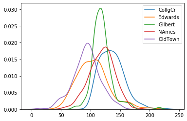

```python
sns.distplot(nhood_series['CollgCr'], hist=False, label='CollgCr');
sns.distplot(nhood_series['Edwards'], hist=False, label='Edwards');
sns.distplot(nhood_series['Gilbert'], hist=False, label='Gilbert');
sns.distplot(nhood_series['NAmes'], hist=False, label='NAmes');
sns.distplot(nhood_series['OldTown'], hist=False, label='OldTown');
```

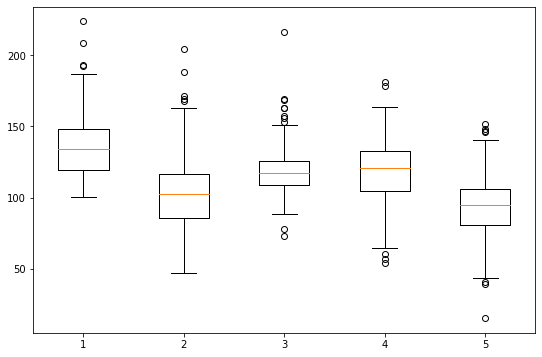

```python
np.random.seed(10)
data = nhood_series.tolist()

# Create a figure instance
fig = plt.figure(1, figsize=(9, 6))

# Create an axes instance
ax = fig.add_subplot(111)

# Create the boxplot
bp = ax.boxplot(data)
```

### Conclusion

*There are more than 30 observations in each group, the distributions are approximately normal, and from the box plots, we can see they have similar range and slightly different outliers, with the p-value less than α, we reject the null hypothesis, and conclude that there are significant price differences among the top 5 neighborhood.*

### Multiway comparison

Use the `multicomp` package to compare the different neighborhoods pairwise.

Hint: You should get one pair where the null hypothesis cannot be rejected.

```python
multicomp = MultiComparison(fam1_select['PriceSqFt'], fam1_select['Neighborhood'], )
ans = multicomp.allpairtest(st.ttest_ind, method='bonf')
```

```python
ans[0]
```

Test Multiple Comparison ttest_ind FWER=0.05 method=bonf alphacSidak=0.01, alphacBonf=0.005

| group1 | group2 | stat | pval | pval_corr | reject |
| --- | --- | --- | --- | --- | --- |
| CollgCr | Edwards | 13.1972 | 0.0 | 0.0 | True |
| CollgCr | Gilbert | 8.7055 | 0.0 | 0.0 | True |
| CollgCr | NAmes | 10.0919 | 0.0 | 0.0 | True |
| CollgCr | OldTown | 20.9784 | 0.0 | 0.0 | True |
| Edwards | Gilbert | -5.7241 | 0.0 | 0.0 | True |
| Edwards | NAmes | -6.639 | 0.0 | 0.0 | True |
| Edwards | OldTown | 4.2133 | 0.0 | 0.0003 | True |
| Gilbert | NAmes | 0.0357 | 0.9715 | 1.0 | False |
| Gilbert | OldTown | 11.9321 | 0.0 | 0.0 | True |
| NAmes | OldTown | 13.7357 | 0.0 | 0.0 | True |

## Question 4: Compute the minimum number of houses that we need to sample to determine if two neighborhoods have sale prices at least \$25 per square foot different.

Use `TTestIndPower` with power = 0.9, alpha=0.05. You'll need to calculate the appropriate effect size.

Hint: Answer around 32.

```python
sample_mean = sum(nhood_series['CollgCr'])/len(nhood_series['CollgCr'])
population_mean = np.mean(fam1_nhood['PriceSqFt'])
sample_standard_deviation = 25

cohens_d = (sample_mean - population_mean)/sample_standard_deviation
```

```python
# parameters for the analysis
effect_size = cohens_d
alpha = 0.05 # significance level
power = 0.9

power_analysis = TTestIndPower()
sample_size = power_analysis.solve_power(effect_size = effect_size,
                                         power = power,
                                         alpha = alpha)

print('Required sample size: {0:.2f}'.format(sample_size))
```

```
Required sample size: 34.88
```